# TASK #1. UNDERSTAND THE PROBLEM STATEMENT

```python
# Let's explore an alternative (smarter) method to deal with missing values
# Let's read the raw data again using Pandas as follows
df = pd.read_csv('Life_Expectancy_Data.csv')
df.head()
```

|  | Year | Status | Life expectancy | Adult Mortality | infant deaths | Alcohol | percentage expenditure | Hepatitis B | Measles | BMI | ... | Polio | Total expenditure | Diphtheria | HIV/AIDS | GDP | Population | thinness 1-19 years | thinness 5-9 years | Income composition of resources | Schooling |
| --- | --- | --- | --- | --- | --- | --- | --- | --- | --- | --- | --- | --- | --- | --- | --- | --- | --- | --- | --- | --- | --- |
| 0 | 2015 | Developing | 65.0 | 263.0 | 62 | 0.01 | 71.279624 | 65.0 | 1154 | 19.1 | ... | 6.0 | 8.16 | 65.0 | 0.1 | 584.259210 | 33736494.0 | 17.2 | 17.3 | 0.479 | 10.1 |
| 1 | 2014 | Developing | 59.9 | 271.0 | 64 | 0.01 | 73.523582 | 62.0 | 492 | 18.6 | ... | 58.0 | 8.18 | 62.0 | 0.1 | 612.696514 | 327582.0 | 17.5 | 17.5 | 0.476 | 10.0 |
| 2 | 2013 | Developing | 59.9 | 268.0 | 66 | 0.01 | 73.219243 | 64.0 | 430 | 18.1 | ... | 62.0 | 8.13 | 64.0 | 0.1 | 631.744976 | 31731688.0 | 17.7 | 17.7 | 0.470 | 9.9 |
| 3 | 2012 | Developing | 59.5 | 272.0 | 69 | 0.01 | 78.184215 | 67.0 | 2787 | 17.6 | ... | 67.0 | 8.52 | 67.0 | 0.1 | 669.959000 | 3696958.0 | 17.9 | 18.0 | 0.463 | 9.8 |
| 4 | 2011 | Developing | 59.2 | 275.0 | 71 | 0.01 | 7.097109 | 68.0 | 3013 | 17.2 | ... | 68.0 | 7.87 | 68.0 | 0.1 | 63.537231 | 2978599.0 | 18.2 | 18.2 | 0.454 | 9.5 |

5 rows × 21 columns

```python
# Calculate the average monthly income
df['GDP'].mean()
```

```
7483.158469138481
```

```python
# You can use Fillna to fill a given column with a certain value
df['GDP'].fillna(df['GDP'].mean(), inplace = True)
```

```python
# Let's check if we still have any missing values
df.isnull().sum()
```

```
Year                                 0
Status                               0
Life expectancy                     10
Adult Mortality                     10
infant deaths                        0
Alcohol                            194
percentage expenditure               0
Hepatitis B                        553
Measles                              0
 BMI                                34
under-five deaths                    0
Polio                               19
Total expenditure                  226
Diphtheria                          19
 HIV/AIDS                            0
GDP                                  0
Population                         652
 thinness  1-19 years               34
 thinness 5-9 years                 34
Income composition of resources    167
Schooling                          163
dtype: int64
```

```python
# bfill/ffill
df.fillna(method='ffill', inplace=True)
# Let's check if we still have any missing values
df.isnull().sum()
```

```
Year                               0
Status                             0
Life expectancy                    0
Adult Mortality                    0
infant deaths                      0
Alcohol                            0
percentage expenditure             0
Hepatitis B                        0
Measles                            0
 BMI                               0
under-five deaths                  0
Polio                              0
Total expenditure                  0
Diphtheria                         0
 HIV/AIDS                          0
GDP                                0
Population                         0
 thinness  1-19 years              0
 thinness 5-9 years                0
Income composition of resources    0
Schooling                          0
dtype: int64
```

```python
# Let's explore interolation method to deal with missing values
# Let's read the raw data again using Pandas as follows
df = pd.read_csv('Life_Expectancy_Data.csv')
```

```python
#fill using interolation
df.interpolate(method ='linear', limit_direction ='forward', inplace=True)
# Let's check if we still have any missing values
df.isnull().sum()
```

```
Year                               0
Status                             0
Life expectancy                    0
Adult Mortality                    0
infant deaths                      0
Alcohol                            0
percentage expenditure             0
Hepatitis B                        0
Measles                            0
 BMI                               0
under-five deaths                  0
Polio                              0
Total expenditure                  0
Diphtheria                         0
 HIV/AIDS                          0
GDP                                0
Population                         0
 thinness  1-19 years              0
 thinness 5-9 years                0
Income composition of resources    0
Schooling                          0
dtype: int64
```

methods : {‘linear’, ‘time’, ‘index’, ‘values’, ‘nearest’, ‘zero’, ‘slinear’, ‘quadratic’, ‘cubic’, ‘barycentric’, ‘krogh’, ‘polynomial’, ‘spline’, ‘piecewise_polynomial’, ‘from_derivatives’, ‘pchip’, ‘akima’}

Linear interpolation is a method of estimating values between two known values in a series of data. In the context of filling missing values in a pandas DataFrame, linear interpolation estimates the missing values by computing a straight line between the two nearest known values. The method assumes that the change in the dependent variable (the missing value) is constant with respect to the independent variable (time or index). The missing value is then estimated as a weighted average of the two nearest known values, where the weight is proportional to the distance between the missing value and the known values.

```python
#droping duplicates
df.drop_duplicates()
```

|  | Year | Status | Life expectancy | Adult Mortality | infant deaths | Alcohol | percentage expenditure | Hepatitis B | Measles | BMI | ... | Polio | Total expenditure | Diphtheria | HIV/AIDS | GDP | Population | thinness 1-19 years | thinness 5-9 years | Income composition of resources | Schooling |
| --- | --- | --- | --- | --- | --- | --- | --- | --- | --- | --- | --- | --- | --- | --- | --- | --- | --- | --- | --- | --- | --- |
| 0 | 2015 | Developing | 65.0 | 263.0 | 62 | 0.01 | 71.279624 | 65.0 | 1154 | 19.1 | ... | 6.0 | 8.16 | 65.0 | 0.1 | 584.259210 | 33736494.0 | 17.2 | 17.3 | 0.479 | 10.1 |
| 1 | 2014 | Developing | 59.9 | 271.0 | 64 | 0.01 | 73.523582 | 62.0 | 492 | 18.6 | ... | 58.0 | 8.18 | 62.0 | 0.1 | 612.696514 | 327582.0 | 17.5 | 17.5 | 0.476 | 10.0 |
| 2 | 2013 | Developing | 59.9 | 268.0 | 66 | 0.01 | 73.219243 | 64.0 | 430 | 18.1 | ... | 62.0 | 8.13 | 64.0 | 0.1 | 631.744976 | 31731688.0 | 17.7 | 17.7 | 0.470 | 9.9 |
| 3 | 2012 | Developing | 59.5 | 272.0 | 69 | 0.01 | 78.184215 | 67.0 | 2787 | 17.6 | ... | 67.0 | 8.52 | 67.0 | 0.1 | 669.959000 | 3696958.0 | 17.9 | 18.0 | 0.463 | 9.8 |
| 4 | 2011 | Developing | 59.2 | 275.0 | 71 | 0.01 | 7.097109 | 68.0 | 3013 | 17.2 | ... | 68.0 | 7.87 | 68.0 | 0.1 | 63.537231 | 2978599.0 | 18.2 | 18.2 | 0.454 | 9.5 |
| ... | ... | ... | ... | ... | ... | ... | ... | ... | ... | ... | ... | ... | ... | ... | ... | ... | ... | ... | ... | ... | ... |
| 2933 | 2004 | Developing | 44.3 | 723.0 | 27 | 4.36 | 0.000000 | 68.0 | 31 | 27.1 | ... | 67.0 | 7.13 | 65.0 | 33.6 | 454.366654 | 12777511.0 | 9.4 | 9.4 | 0.407 | 9.2 |
| 2934 | 2003 | Developing | 44.5 | 715.0 | 26 | 4.06 | 0.000000 | 7.0 | 998 | 26.7 | ... | 7.0 | 6.52 | 68.0 | 36.7 | 453.351155 | 12633897.0 | 9.8 | 9.9 | 0.418 | 9.5 |
| 2935 | 2002 | Developing | 44.8 | 73.0 | 25 | 4.43 | 0.000000 | 73.0 | 304 | 26.3 | ... | 73.0 | 6.53 | 71.0 | 39.8 | 57.348340 | 125525.0 | 1.2 | 1.3 | 0.427 | 10.0 |
| 2936 | 2001 | Developing | 45.3 | 686.0 | 25 | 1.72 | 0.000000 | 76.0 | 529 | 25.9 | ... | 76.0 | 6.16 | 75.0 | 42.1 | 548.587312 | 12366165.0 | 1.6 | 1.7 | 0.427 | 9.8 |
| 2937 | 2000 | Developing | 46.0 | 665.0 | 24 | 1.68 | 0.000000 | 79.0 | 1483 | 25.5 | ... | 78.0 | 7.10 | 78.0 | 43.5 | 547.358879 | 12222251.0 | 11.0 | 11.2 | 0.434 | 9.8 |

2938 rows × 21 columns

**PRACTICE OPPORTUNITY #2 [OPTIONAL]:**

- **Calculate the median total expenditure**
- **Use the calculated median values to fill out missing data in the total expenditure column**
- **Confirm that the process is successful**

# TASK #4: DATA-TYPE CONVERSION AND ONE-HOT ENCODING

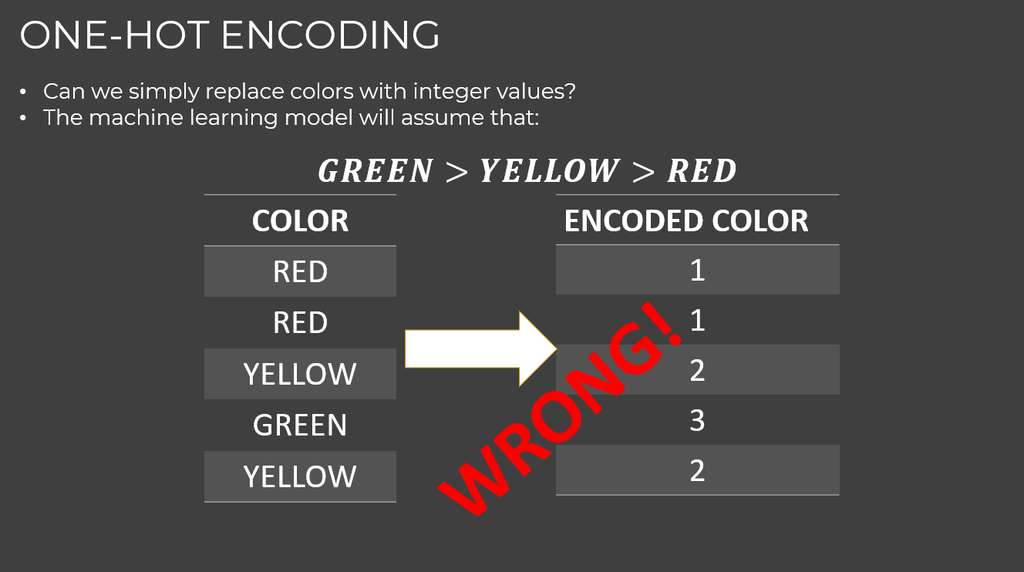

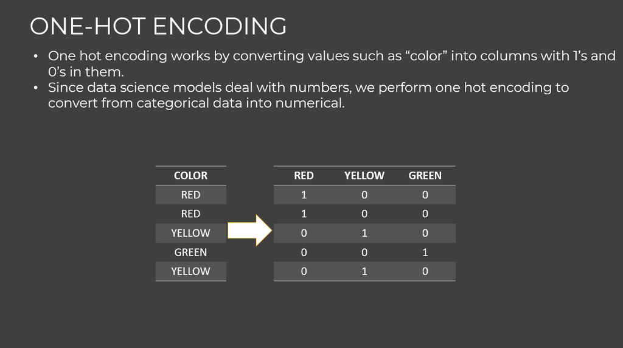

**Working with Data-types**

```python
# Let's load a file with datatype errors
columns=['education', 'age', 'capital-gain', 'race', 'capital-loss',
         'hours-per-week', 'gender', 'classification']
df =  pd.read_csv('census.csv',names=columns, header=None)
```

```python
df.head()
```

|  | education | age | capital-gain | race | capital-loss | hours-per-week | gender | classification |
| --- | --- | --- | --- | --- | --- | --- | --- | --- |
| 0 | Bachelors | 39 | 2174 | White | 0 | 40 | Male | <=50K |
| 1 | Bachelors | 50 | ? | White | 0 | 13 | Male | <=50K |
| 2 | HS-grad | 38 | ? | White | 0 | 40 | Male | <=50K |
| 3 | 11th | 53 | ? | Black | 0 | 40 | Male | <=50K |
| 4 | Bachelors | 28 | 0 | Black | 0 | 40 | Female | <=50K |

```python
# lets look at the data types
df.dtypes
```

[output not shown]

If your data types don't look the way you expected them, explicitly convert them to the desired type using the .to_datetime(), .to_numeric() etc.

```python
df['capital-gain'] = pd.to_numeric(df['capital-gain'],errors='coerce')
```

```python
# Let's look at the updated data type
df.dtypes
```

[output not shown]

Take note how to_numeric properly converts to decimal or integer depending on the data it finds. The errors='coerce' parameter instructs Pandas to enter a NaN at any field where the conversion fails.

errors{‘ignore’, ‘raise’, ‘coerce’}, default ‘raise’

If ‘raise’, then invalid parsing will raise an exception.

If ‘coerce’, then invalid parsing will be set as NaN.

If ‘ignore’, then invalid parsing will return the input.

**Categorical nominal encoding**

```python
df.gender = df.gender.astype('category').cat.codes
```

```python
df.head()
```

[output not shown]

```python
#Label Encoding
df.classification = df.classification.astype('category').cat.codes
df.head()
```

|  | education | age | capital-gain | race | capital-loss | hours-per-week | gender | classification |
| --- | --- | --- | --- | --- | --- | --- | --- | --- |
| 0 | Bachelors | 39 | 2174.0 | White | 0 | 40 | 1 | 0 |
| 1 | Bachelors | 50 | NaN | White | 0 | 13 | 1 | 0 |
| 2 | HS-grad | 38 | NaN | White | 0 | 40 | 1 | 0 |
| 3 | 11th | 53 | NaN | Black | 0 | 40 | 1 | 0 |
| 4 | Bachelors | 28 | 0.0 | Black | 0 | 40 | 0 | 0 |

**Categorical Ordinal Encoding**

```python
from pandas.api.types import CategoricalDtype
categories=['Preschool', '1st-4th', '5th-6th', '7th-8th', '10th', '9th', '12th', '11th',
            'Some-college', 'HS-grad', 'Bachelors', 'Masters', 'Doctorate']
Dtype = CategoricalDtype(categories=categories, ordered=True)
```

```python
df.education=df.education.astype(Dtype).cat.codes
```

```python
df.head()
```

|  | education | age | capital-gain | race | capital-loss | hours-per-week | gender | classification |
| --- | --- | --- | --- | --- | --- | --- | --- | --- |
| 0 | 10 | 39 | 2174.0 | White | 0 | 40 | 1 | 0 |
| 1 | 10 | 50 | NaN | White | 0 | 13 | 1 | 0 |
| 2 | 9 | 38 | NaN | White | 0 | 40 | 1 | 0 |
| 3 | 7 | 53 | NaN | Black | 0 | 40 | 1 | 0 |
| 4 | 10 | 28 | 0.0 | Black | 0 | 40 | 0 | 0 |

**One Hot Encoding**

```python
df = pd.get_dummies(df,columns=['race'])
```

```python
df.head()
```

[output not shown]

# TASK #1: Data Integration

```python
uber1 = pd.read_csv('uber1.csv')
uber2 = pd.read_csv('uber2.csv')
uber3 = pd.read_csv('uber3.csv')
```

```python
uber1.head()
```

|  | Unnamed: 0 | Date/Time | Lat | Lon | Base |
| --- | --- | --- | --- | --- | --- |
| 0 | 42 | 5/1/2014 3:50:00 | 40.7299 | -73.9868 | B02512 |
| 1 | 43 | 5/1/2014 3:57:00 | 40.7762 | -73.9499 | B02512 |
| 2 | 44 | 5/1/2014 3:58:00 | 40.7538 | -73.9774 | B02512 |
| 3 | 45 | 5/1/2014 3:58:00 | 40.6819 | -73.6850 | B02512 |
| 4 | 46 | 5/1/2014 4:04:00 | 40.7580 | -73.9892 | B02512 |

```python
# Concatenate uber1, uber2, and uber3: row_concat
row_concat = pd.concat([uber1,uber2,uber3])
```

```python
row_concat.shape
```

```
(312, 5)
```

```python
df1 = pd.DataFrame(
    {
        "A": ["A0", "A1", "A2", "A3"],
        "B": ["B0", "B1", "B2", "B3"],
        "C": ["C0", "C1", "C2", "C3"],
        "D": ["D0", "D1", "D2", "D3"],
    },
    index=[0, 1, 2, 3],
)
df2 = pd.DataFrame(
    {
        "A": ["A4", "A5", "A6", "A7"],
        "B": ["B4", "B5", "B6", "B7"],
        "C": ["C4", "C5", "C6", "C7"],
        "D": ["D4", "D5", "D6", "D7"],
    },
    index=[4, 5, 6, 7],
)
df3 = pd.DataFrame(
    {
        "B": ["B2", "B3", "B6", "B7"],
        "D": ["D2", "D3", "D6", "D7"],
        "F": ["F2", "F3", "F6", "F7"],
    },
    index=[2, 3, 6, 7],
)
```

```python
print(df1.head())
print(df2.head())
print(df3.head())
```

```
    A   B   C   D
0  A0  B0  C0  D0
1  A1  B1  C1  D1
2  A2  B2  C2  D2
3  A3  B3  C3  D3
    A   B   C   D
4  A4  B4  C4  D4
5  A5  B5  C5  D5
6  A6  B6  C6  D6
7  A7  B7  C7  D7
    B   D   F
2  B2  D2  F2
3  B3  D3  F3
6  B6  D6  F6
7  B7  D7  F7
```

```python
pd.concat([df1, df3], axis=1)
```

|  | A | B | C | D | B | D | F |
| --- | --- | --- | --- | --- | --- | --- | --- |
| 0 | A0 | B0 | C0 | D0 | NaN | NaN | NaN |
| 1 | A1 | B1 | C1 | D1 | NaN | NaN | NaN |
| 2 | A2 | B2 | C2 | D2 | B2 | D2 | F2 |
| 3 | A3 | B3 | C3 | D3 | B3 | D3 | F3 |
| 6 | NaN | NaN | NaN | NaN | B6 | D6 | F6 |
| 7 | NaN | NaN | NaN | NaN | B7 | D7 | F7 |

```python
pd.concat([df1, df3], axis=1, join="inner")
```

|  | A | B | C | D | B | D | F |
| --- | --- | --- | --- | --- | --- | --- | --- |
| 2 | A2 | B2 | C2 | D2 | B2 | D2 | F2 |
| 3 | A3 | B3 | C3 | D3 | B3 | D3 | F3 |

```python
# Merging
left = pd.DataFrame(
    {
        "key": ["K0", "K1", "K2", "K3"],
        "A": ["A0", "A1", "A2", "A3"],
        "B": ["B0", "B1", "B2", "B3"],
    }
)


right = pd.DataFrame(
    {
        "key": ["K0", "K1", "K2", "K3"],
        "C": ["C0", "C1", "C2", "C3"],
        "D": ["D0", "D1", "D2", "D3"],
    }
)
```

```python
pd.merge(left, right, on="key")
```

|  | key | A | B | C | D |
| --- | --- | --- | --- | --- | --- |
| 0 | K0 | A0 | B0 | C0 | D0 |
| 1 | K1 | A1 | B1 | C1 | D1 |
| 2 | K2 | A2 | B2 | C2 | D2 |
| 3 | K3 | A3 | B3 | C3 | D3 |

```python
left = pd.DataFrame(
    {
        "key1": ["K0", "K0", "K1", "K2"],
        "key2": ["K0", "K1", "K0", "K1"],
        "A": ["A0", "A1", "A2", "A3"],
        "B": ["B0", "B1", "B2", "B3"],
    }
)


right = pd.DataFrame(
    {
        "key1": ["K0", "K1", "K1", "K2"],
        "key2": ["K0", "K0", "K0", "K0"],
        "C": ["C0", "C1", "C2", "C3"],
        "D": ["D0", "D1", "D2", "D3"],
    }
)
```

```python
pd.merge(left, right, how="left", on=["key1", "key2"])
```

|  | key1 | key2 | A | B | C | D |
| --- | --- | --- | --- | --- | --- | --- |
| 0 | K0 | K0 | A0 | B0 | C0 | D0 |
| 1 | K0 | K1 | A1 | B1 | NaN | NaN |
| 2 | K1 | K0 | A2 | B2 | C1 | D1 |
| 3 | K1 | K0 | A2 | B2 | C2 | D2 |
| 4 | K2 | K1 | A3 | B3 | NaN | NaN |

In Python Pandas, concat and merge are used to combine dataframes in different ways.

In general, concat is a simpler operation and is useful when you want to combine dataframes without any regard for shared columns or indices. merge is more powerful and is useful when you want to combine dataframes based on shared columns or indices.

```python
#Reshaping the data using melt
airquality = pd.read_csv('airquality.csv')
# Print the head of airquality
airquality.head()
```

|  | Ozone | Solar.R | Wind | Temp | Month | Day |
| --- | --- | --- | --- | --- | --- | --- |
| 0 | 41.0 | 190.0 | 7.4 | 67 | 5 | 1 |
| 1 | 36.0 | 118.0 | 8.0 | 72 | 5 | 2 |
| 2 | 12.0 | 149.0 | 12.6 | 74 | 5 | 3 |
| 3 | 18.0 | 313.0 | 11.5 | 62 | 5 | 4 |
| 4 | NaN | NaN | 14.3 | 56 | 5 | 5 |

```python
# Melt airquality: airquality_melt
airquality_melt = pd.melt(airquality, id_vars=['Month', 'Day'])
```

```python
# Print the head of airquality_melt
airquality_melt.head()
```

|  | Month | Day | variable | value |
| --- | --- | --- | --- | --- |
| 0 | 5 | 1 | Ozone | 41.0 |
| 1 | 5 | 2 | Ozone | 36.0 |
| 2 | 5 | 3 | Ozone | 12.0 |
| 3 | 5 | 4 | Ozone | 18.0 |
| 4 | 5 | 5 | Ozone | NaN |

```python
# Melt airquality: airquality_melt
airquality_melt = pd.melt(airquality, id_vars=['Month', 'Day'],
                          var_name='measurement', value_name='reading')
```

```python
# Print the head of airquality_melt
airquality_melt.head()
```

|  | Month | Day | measurement | reading |
| --- | --- | --- | --- | --- |
| 0 | 5 | 1 | Ozone | 41.0 |
| 1 | 5 | 2 | Ozone | 36.0 |
| 2 | 5 | 3 | Ozone | 12.0 |
| 3 | 5 | 4 | Ozone | 18.0 |
| 4 | 5 | 5 | Ozone | NaN |

Pivot Data

```python
airquality_pivot = airquality_melt.pivot_table(index=['Month', 'Day'],
                                               columns='measurement',
                                               values='reading')
```

```python
airquality_pivot.head()
```

| Month | measurement Day | Ozone | Solar.R | Temp | Wind |
| --- | --- | --- | --- | --- | --- |
| 5 | 1 | 41.0 | 190.0 | 67.0 | 7.4 |
|  | 2 | 36.0 | 118.0 | 72.0 | 8.0 |
|  | 3 | 12.0 | 149.0 | 74.0 | 12.6 |
|  | 4 | 18.0 | 313.0 | 62.0 | 11.5 |
|  | 5 | NaN | NaN | 56.0 | 14.3 |

```python
# Reset the index of airquality_pivot: airquality_pivot
airquality_pivot = airquality_pivot.reset_index()
```

```python
airquality_pivot.head()
```

| measurement | Month | Day | Ozone | Solar.R | Temp | Wind |
| --- | --- | --- | --- | --- | --- | --- |
| 0 | 5 | 1 | 41.0 | 190.0 | 67.0 | 7.4 |
| 1 | 5 | 2 | 36.0 | 118.0 | 72.0 | 8.0 |
| 2 | 5 | 3 | 12.0 | 149.0 | 74.0 | 12.6 |
| 3 | 5 | 4 | 18.0 | 313.0 | 62.0 | 11.5 |
| 4 | 5 | 5 | NaN | NaN | 56.0 | 14.3 |

# TASK #1: TRANSFORMATION: PERFORM NORMALIZATION

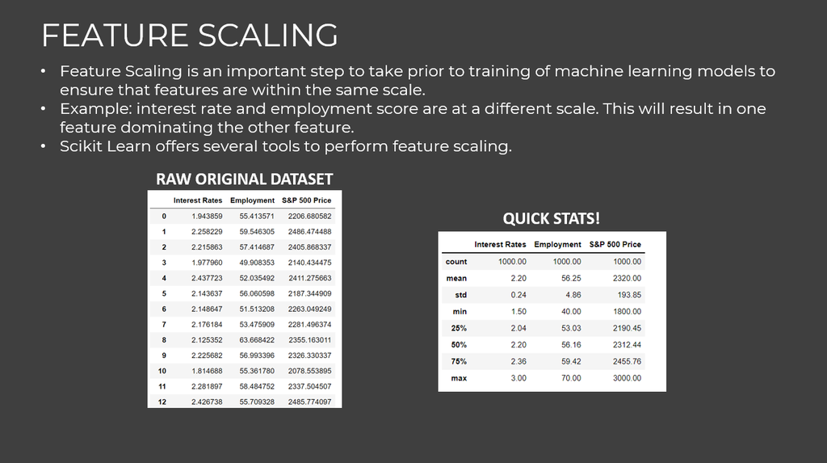

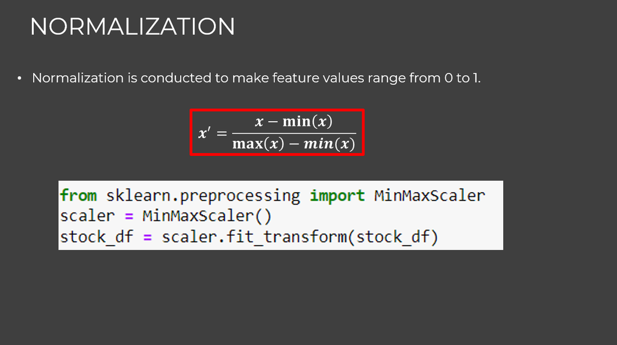

```python
data = {'Age': [25, 30, 35, 40, 45],
'Income': [50000, 60000, 75000, 90000, 100000]}

df = pd.DataFrame(data)
df
```

|  | Age | Income |
| --- | --- | --- |
| 0 | 25 | 50000 |
| 1 | 30 | 60000 |
| 2 | 35 | 75000 |
| 3 | 40 | 90000 |
| 4 | 45 | 100000 |

```python
# Min-Max Scaling
min_age = df['Age'].min()
max_age = df['Age'].max()
min_income = df['Income'].min()
max_income = df['Income'].max()

df['Scaled_Age'] = (df['Age'] - min_age) / (max_age - min_age)
df['Scaled_Income'] = (df['Income'] - min_income) / (max_income - min_income)

df
```

|  | Age | Income | Scaled_Age | Scaled_Income |
| --- | --- | --- | --- | --- |
| 0 | 25 | 50000 | 0.00 | 0.0 |
| 1 | 30 | 60000 | 0.25 | 0.2 |
| 2 | 35 | 75000 | 0.50 | 0.5 |
| 3 | 40 | 90000 | 0.75 | 0.8 |
| 4 | 45 | 100000 | 1.00 | 1.0 |

```python
# Let's read a CSV file using Pandas as follows
df = pd.read_csv('Life_Expectancy_Data.csv')
df
```

```python
df['Life expectancy '].values
```

```python
# Normalization is conducted to make feature values range from 0 to 1
from sklearn.preprocessing import MinMaxScaler
scaler = MinMaxScaler()
df['Life expectancy '] = scaler.fit_transform(df['Life expectancy '].values.reshape(-1,1))
```

```python
import numpy as np
np.array([1,2,3,4,5]).reshape(-1,1).shape
```

```
(5, 1)
```

```python
df['Life expectancy ']
```

```python
round(df['Life expectancy '].describe())
```

[output not shown]

# TASK #2: PERFORM STANDARDIZATION

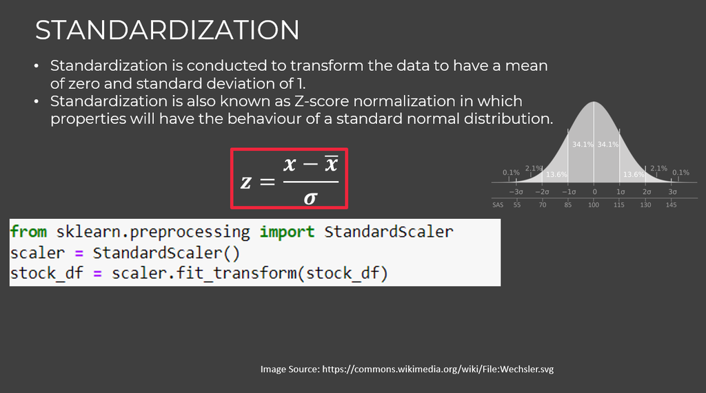

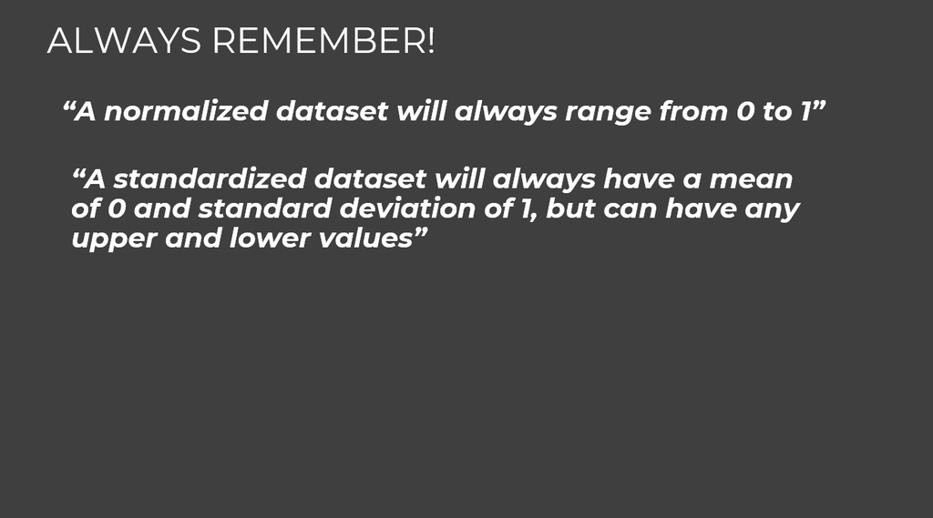

```python
data = {'Age': [25, 30, 35, 40, 45],
'Income': [50000, 60000, 75000, 90000, 100000]}

df = pd.DataFrame(data)
df
```

|  | Age | Income |
| --- | --- | --- |
| 0 | 25 | 50000 |
| 1 | 30 | 60000 |
| 2 | 35 | 75000 |
| 3 | 40 | 90000 |
| 4 | 45 | 100000 |

```python
# Standarization
mean_age = df['Age'].mean()
std_age = df['Age'].std()
mean_income = df['Income'].mean()
std_income = df['Income'].std()

df['Normalized_Age'] = (df['Age'] - mean_age) / std_age
df['Normalized_Income'] = (df['Income'] - mean_income) / std_income

df
```

|  | Age | Income | Normalized_Age | Normalized_Income |
| --- | --- | --- | --- | --- |
| 0 | 25 | 50000 | -1.264911 | -1.212678 |
| 1 | 30 | 60000 | -0.632456 | -0.727607 |
| 2 | 35 | 75000 | 0.000000 | 0.000000 |
| 3 | 40 | 90000 | 0.632456 | 0.727607 |
| 4 | 45 | 100000 | 1.264911 | 1.212678 |

```python
df.describe()
```

|  | Age | Income | Normalized_Age | Normalized_Income |
| --- | --- | --- | --- | --- |
| count | 5.000000 | 5.000000 | 5.000000e+00 | 5.000000 |
| mean | 35.000000 | 75000.000000 | 4.440892e-17 | 0.000000 |
| std | 7.905694 | 20615.528128 | 1.000000e+00 | 1.000000 |
| min | 25.000000 | 50000.000000 | -1.264911e+00 | -1.212678 |
| 25% | 30.000000 | 60000.000000 | -6.324555e-01 | -0.727607 |
| 50% | 35.000000 | 75000.000000 | 0.000000e+00 | 0.000000 |
| 75% | 40.000000 | 90000.000000 | 6.324555e-01 | 0.727607 |
| max | 45.000000 | 100000.000000 | 1.264911e+00 | 1.212678 |

```python
# Let's read a CSV file using Pandas as follows
df = pd.read_csv('Life_Expectancy_Data.csv')
df
```

```python
df['Life expectancy '].values
```

```python
# Normalization is conducted to make feature values range from 0 to 1
from sklearn.preprocessing import StandardScaler
scaler = StandardScaler()
df['Life expectancy '] = scaler.fit_transform(df['Life expectancy '].values.reshape(-1,1))
```

```python
df['Life expectancy ']
```

```python
round(df['Life expectancy '].describe())
```

[output not shown]

# TASK #3. DIMENTIONALITY REDUCTION

```python
import numpy as np
import pandas as pd
from scipy import linalg
```

```python
X = np.array([[20,50,4],[25,60,5],[30,65,5.5],[40,75,6]])
```

```python
data = pd.DataFrame(X,columns=["age","weight","height"])
data
```

|  | age | weight | height |
| --- | --- | --- | --- |
| 0 | 20.0 | 50.0 | 4.0 |
| 1 | 25.0 | 60.0 | 5.0 |
| 2 | 30.0 | 65.0 | 5.5 |
| 3 | 40.0 | 75.0 | 6.0 |

```python
X = np.array(X)
#mean of each column
M=np.mean(X, axis=0)
print(M)
#center columns by subtracting mean
C= X-M
print(C)
# calculate covariance matrix
#V=np.cov(C,rowvar = False)
V=np.cov(C.T)
print(V)
```

```
[28.75  62.5    5.125]
[[ -8.75  -12.5    -1.125]
 [ -3.75   -2.5    -0.125]
 [  1.25    2.5     0.375]
 [ 11.25   12.5     0.875]]
[[ 72.91666667  87.5          6.875     ]
 [ 87.5        108.33333333   8.75      ]
 [  6.875        8.75         0.72916667]]
```

```python
#calculate eigen vectors and values
eigen_values, eigen_vectors = linalg.eig(V)
print(eigen_values)
print(eigen_vectors)
```

```
[1.80587147e+02+0.j 1.38624052e+00+0.j 5.77924152e-03+0.j]
[[ 0.63183775  0.77042797  0.08498117]
 [ 0.77263783 -0.61729995 -0.14822808]
 [ 0.06174019 -0.15931576  0.9852952 ]]
```

```python
#check explained variance ratio of each component
print(eigen_values[0]/np.sum(eigen_values))
print(eigen_values[1]/np.sum(eigen_values))
print(eigen_values[2]/np.sum(eigen_values))
```

```
(0.9923506641518309+0j)
(0.007617578138632018+0j)
(3.175770953700823e-05+0j)
```

```python
#sort the eigenvalues in descending order
sorted_index = np.argsort(eigen_values)[::-1]
print(sorted_index)
sorted_eigenvalue = eigen_values[sorted_index]
print(sorted_eigenvalue)
#similarly sort the eigenvectors
sorted_eigenvectors = eigen_vectors[:,sorted_index]
print(sorted_eigenvectors)
```

```
[0 1 2]
[1.80587147e+02+0.j 1.38624052e+00+0.j 5.77924152e-03+0.j]
[[ 0.63183775  0.77042797  0.08498117]
 [ 0.77263783 -0.61729995 -0.14822808]
 [ 0.06174019 -0.15931576  0.9852952 ]]
```

```python
# select the first n eigenvectors, n is desired dimension
# of our final reduced data.

n_components = 2 #you can select any number of components.
eigenvector_subset = sorted_eigenvectors[:,0:n_components]
```

```python
eigenvector_subset.shape
```

```
(3, 2)
```

```python
X_reduced = np.dot(C,  eigenvector_subset)
X_reduced
```

```
array([[-15.25601083,   1.15423481],
       [ -4.30870364,  -1.32594056],
       [  2.74454432,  -0.63995831],
       [ 16.82017015,   0.81166407]])
```

```python
X_reduced = np.dot(eigenvector_subset.transpose() , C.transpose() ).transpose()
X_reduced
```

```
array([[-15.25601083,   1.15423481],
       [ -4.30870364,  -1.32594056],
       [  2.74454432,  -0.63995831],
       [ 16.82017015,   0.81166407]])
```

```python
#new dataframe with reduced features
df = pd.DataFrame(X_reduced,columns=["PC1","PC2"])
df
```

|  | PC1 | PC2 |
| --- | --- | --- |
| 0 | -15.256011 | 1.154235 |
| 1 | -4.308704 | -1.325941 |
| 2 | 2.744544 | -0.639958 |
| 3 | 16.820170 | 0.811664 |

```python
# Let's read a CSV file using Pandas as follows
df = pd.read_csv('Life_Expectancy_Data.csv')
df
```

|  | Year | Status | Life expectancy | Adult Mortality | infant deaths | Alcohol | percentage expenditure | Hepatitis B | Measles | BMI | ... | Polio | Total expenditure | Diphtheria | HIV/AIDS | GDP | Population | thinness 1-19 years | thinness 5-9 years | Income composition of resources | Schooling |
| --- | --- | --- | --- | --- | --- | --- | --- | --- | --- | --- | --- | --- | --- | --- | --- | --- | --- | --- | --- | --- | --- |
| 0 | 2015 | Developing | 65.0 | 263.0 | 62 | 0.01 | 71.279624 | 65.0 | 1154 | 19.1 | ... | 6.0 | 8.16 | 65.0 | 0.1 | 584.259210 | 33736494.0 | 17.2 | 17.3 | 0.479 | 10.1 |
| 1 | 2014 | Developing | 59.9 | 271.0 | 64 | 0.01 | 73.523582 | 62.0 | 492 | 18.6 | ... | 58.0 | 8.18 | 62.0 | 0.1 | 612.696514 | 327582.0 | 17.5 | 17.5 | 0.476 | 10.0 |
| 2 | 2013 | Developing | 59.9 | 268.0 | 66 | 0.01 | 73.219243 | 64.0 | 430 | 18.1 | ... | 62.0 | 8.13 | 64.0 | 0.1 | 631.744976 | 31731688.0 | 17.7 | 17.7 | 0.470 | 9.9 |
| 3 | 2012 | Developing | 59.5 | 272.0 | 69 | 0.01 | 78.184215 | 67.0 | 2787 | 17.6 | ... | 67.0 | 8.52 | 67.0 | 0.1 | 669.959000 | 3696958.0 | 17.9 | 18.0 | 0.463 | 9.8 |
| 4 | 2011 | Developing | 59.2 | 275.0 | 71 | 0.01 | 7.097109 | 68.0 | 3013 | 17.2 | ... | 68.0 | 7.87 | 68.0 | 0.1 | 63.537231 | 2978599.0 | 18.2 | 18.2 | 0.454 | 9.5 |
| ... | ... | ... | ... | ... | ... | ... | ... | ... | ... | ... | ... | ... | ... | ... | ... | ... | ... | ... | ... | ... | ... |
| 2933 | 2004 | Developing | 44.3 | 723.0 | 27 | 4.36 | 0.000000 | 68.0 | 31 | 27.1 | ... | 67.0 | 7.13 | 65.0 | 33.6 | 454.366654 | 12777511.0 | 9.4 | 9.4 | 0.407 | 9.2 |
| 2934 | 2003 | Developing | 44.5 | 715.0 | 26 | 4.06 | 0.000000 | 7.0 | 998 | 26.7 | ... | 7.0 | 6.52 | 68.0 | 36.7 | 453.351155 | 12633897.0 | 9.8 | 9.9 | 0.418 | 9.5 |
| 2935 | 2002 | Developing | 44.8 | 73.0 | 25 | 4.43 | 0.000000 | 73.0 | 304 | 26.3 | ... | 73.0 | 6.53 | 71.0 | 39.8 | 57.348340 | 125525.0 | 1.2 | 1.3 | 0.427 | 10.0 |
| 2936 | 2001 | Developing | 45.3 | 686.0 | 25 | 1.72 | 0.000000 | 76.0 | 529 | 25.9 | ... | 76.0 | 6.16 | 75.0 | 42.1 | 548.587312 | 12366165.0 | 1.6 | 1.7 | 0.427 | 9.8 |
| 2937 | 2000 | Developing | 46.0 | 665.0 | 24 | 1.68 | 0.000000 | 79.0 | 1483 | 25.5 | ... | 78.0 | 7.10 | 78.0 | 43.5 | 547.358879 | 12222251.0 | 11.0 | 11.2 | 0.434 | 9.8 |

2938 rows × 21 columns

```python
from sklearn.decomposition import PCA
pca = PCA(n_components=10)
df.Status = df.Status.astype('category').cat.codes
df.dropna(inplace=True)
pca.fit(df)

print(pca.explained_variance_ratio_)
```

```
[9.99999954e-01 2.73014606e-08 1.81556915e-08 4.86565750e-11
 3.79911214e-12 2.89747142e-12 2.06450608e-13 6.45646869e-14
 6.02865788e-14 3.47533104e-14]
```

```python
pca.transform(df).shape
```

```
(1649, 10)
```

# TASK #4. PANDAS WITH FUNCTIONS

```python
# Let's read a CSV file using Pandas as follows
df = pd.read_csv('Life_Expectancy_Data.csv')
df
```

|  | Year | Status | Life expectancy | Adult Mortality | infant deaths | Alcohol | percentage expenditure | Hepatitis B | Measles | BMI | ... | Polio | Total expenditure | Diphtheria | HIV/AIDS | GDP | Population | thinness 1-19 years | thinness 5-9 years | Income composition of resources | Schooling |
| --- | --- | --- | --- | --- | --- | --- | --- | --- | --- | --- | --- | --- | --- | --- | --- | --- | --- | --- | --- | --- | --- |
| 0 | 2015 | Developing | 65.0 | 263.0 | 62 | 0.01 | 71.279624 | 65.0 | 1154 | 19.1 | ... | 6.0 | 8.16 | 65.0 | 0.1 | 584.259210 | 33736494.0 | 17.2 | 17.3 | 0.479 | 10.1 |
| 1 | 2014 | Developing | 59.9 | 271.0 | 64 | 0.01 | 73.523582 | 62.0 | 492 | 18.6 | ... | 58.0 | 8.18 | 62.0 | 0.1 | 612.696514 | 327582.0 | 17.5 | 17.5 | 0.476 | 10.0 |
| 2 | 2013 | Developing | 59.9 | 268.0 | 66 | 0.01 | 73.219243 | 64.0 | 430 | 18.1 | ... | 62.0 | 8.13 | 64.0 | 0.1 | 631.744976 | 31731688.0 | 17.7 | 17.7 | 0.470 | 9.9 |
| 3 | 2012 | Developing | 59.5 | 272.0 | 69 | 0.01 | 78.184215 | 67.0 | 2787 | 17.6 | ... | 67.0 | 8.52 | 67.0 | 0.1 | 669.959000 | 3696958.0 | 17.9 | 18.0 | 0.463 | 9.8 |
| 4 | 2011 | Developing | 59.2 | 275.0 | 71 | 0.01 | 7.097109 | 68.0 | 3013 | 17.2 | ... | 68.0 | 7.87 | 68.0 | 0.1 | 63.537231 | 2978599.0 | 18.2 | 18.2 | 0.454 | 9.5 |
| ... | ... | ... | ... | ... | ... | ... | ... | ... | ... | ... | ... | ... | ... | ... | ... | ... | ... | ... | ... | ... | ... |
| 2933 | 2004 | Developing | 44.3 | 723.0 | 27 | 4.36 | 0.000000 | 68.0 | 31 | 27.1 | ... | 67.0 | 7.13 | 65.0 | 33.6 | 454.366654 | 12777511.0 | 9.4 | 9.4 | 0.407 | 9.2 |
| 2934 | 2003 | Developing | 44.5 | 715.0 | 26 | 4.06 | 0.000000 | 7.0 | 998 | 26.7 | ... | 7.0 | 6.52 | 68.0 | 36.7 | 453.351155 | 12633897.0 | 9.8 | 9.9 | 0.418 | 9.5 |
| 2935 | 2002 | Developing | 44.8 | 73.0 | 25 | 4.43 | 0.000000 | 73.0 | 304 | 26.3 | ... | 73.0 | 6.53 | 71.0 | 39.8 | 57.348340 | 125525.0 | 1.2 | 1.3 | 0.427 | 10.0 |
| 2936 | 2001 | Developing | 45.3 | 686.0 | 25 | 1.72 | 0.000000 | 76.0 | 529 | 25.9 | ... | 76.0 | 6.16 | 75.0 | 42.1 | 548.587312 | 12366165.0 | 1.6 | 1.7 | 0.427 | 9.8 |
| 2937 | 2000 | Developing | 46.0 | 665.0 | 24 | 1.68 | 0.000000 | 79.0 | 1483 | 25.5 | ... | 78.0 | 7.10 | 78.0 | 43.5 | 547.358879 | 12222251.0 | 11.0 | 11.2 | 0.434 | 9.8 |

2938 rows × 21 columns

```python
# Let's assume the percentage expenditure has increased by 5
# Define a function that increases all elements by a fixed value of 5% (for simplicity sake)
def percentage_expenditure_update(balance):
    return balance + 5
```

```python
# You can apply a function to the DataFrame
df['percentage expenditure'] = df['percentage expenditure'].apply(percentage_expenditure_update)
df
```

|  | Year | Status | Life expectancy | Adult Mortality | infant deaths | Alcohol | percentage expenditure | Hepatitis B | Measles | BMI | ... | Polio | Total expenditure | Diphtheria | HIV/AIDS | GDP | Population | thinness 1-19 years | thinness 5-9 years | Income composition of resources | Schooling |
| --- | --- | --- | --- | --- | --- | --- | --- | --- | --- | --- | --- | --- | --- | --- | --- | --- | --- | --- | --- | --- | --- |
| 0 | 2015 | Developing | 65.0 | 263.0 | 62 | 0.01 | 76.279624 | 65.0 | 1154 | 19.1 | ... | 6.0 | 8.16 | 65.0 | 0.1 | 584.259210 | 33736494.0 | 17.2 | 17.3 | 0.479 | 10.1 |
| 1 | 2014 | Developing | 59.9 | 271.0 | 64 | 0.01 | 78.523582 | 62.0 | 492 | 18.6 | ... | 58.0 | 8.18 | 62.0 | 0.1 | 612.696514 | 327582.0 | 17.5 | 17.5 | 0.476 | 10.0 |
| 2 | 2013 | Developing | 59.9 | 268.0 | 66 | 0.01 | 78.219243 | 64.0 | 430 | 18.1 | ... | 62.0 | 8.13 | 64.0 | 0.1 | 631.744976 | 31731688.0 | 17.7 | 17.7 | 0.470 | 9.9 |
| 3 | 2012 | Developing | 59.5 | 272.0 | 69 | 0.01 | 83.184215 | 67.0 | 2787 | 17.6 | ... | 67.0 | 8.52 | 67.0 | 0.1 | 669.959000 | 3696958.0 | 17.9 | 18.0 | 0.463 | 9.8 |
| 4 | 2011 | Developing | 59.2 | 275.0 | 71 | 0.01 | 12.097109 | 68.0 | 3013 | 17.2 | ... | 68.0 | 7.87 | 68.0 | 0.1 | 63.537231 | 2978599.0 | 18.2 | 18.2 | 0.454 | 9.5 |
| ... | ... | ... | ... | ... | ... | ... | ... | ... | ... | ... | ... | ... | ... | ... | ... | ... | ... | ... | ... | ... | ... |
| 2933 | 2004 | Developing | 44.3 | 723.0 | 27 | 4.36 | 5.000000 | 68.0 | 31 | 27.1 | ... | 67.0 | 7.13 | 65.0 | 33.6 | 454.366654 | 12777511.0 | 9.4 | 9.4 | 0.407 | 9.2 |
| 2934 | 2003 | Developing | 44.5 | 715.0 | 26 | 4.06 | 5.000000 | 7.0 | 998 | 26.7 | ... | 7.0 | 6.52 | 68.0 | 36.7 | 453.351155 | 12633897.0 | 9.8 | 9.9 | 0.418 | 9.5 |
| 2935 | 2002 | Developing | 44.8 | 73.0 | 25 | 4.43 | 5.000000 | 73.0 | 304 | 26.3 | ... | 73.0 | 6.53 | 71.0 | 39.8 | 57.348340 | 125525.0 | 1.2 | 1.3 | 0.427 | 10.0 |
| 2936 | 2001 | Developing | 45.3 | 686.0 | 25 | 1.72 | 5.000000 | 76.0 | 529 | 25.9 | ... | 76.0 | 6.16 | 75.0 | 42.1 | 548.587312 | 12366165.0 | 1.6 | 1.7 | 0.427 | 9.8 |
| 2937 | 2000 | Developing | 46.0 | 665.0 | 24 | 1.68 | 5.000000 | 79.0 | 1483 | 25.5 | ... | 78.0 | 7.10 | 78.0 | 43.5 | 547.358879 | 12222251.0 | 11.0 | 11.2 | 0.434 | 9.8 |

2938 rows × 21 columns

# HOME TASK OVERVIEW

- In this project, we will perform basic Exploratory Data Analysis (EDA) on the Kyphosis disease Dataset.
- Kyphosis is an abnormally excessive convex curvature of the spine.
- Dataset contains 81 rows and 4 columns representing data on children who have had corrective spinal surgery.
  - INPUTS: 1. Age: in months, 2. Number: the number of vertebrae involved, 3. Start: the number of the first (topmost) vertebra operated on.
  - OUTPUTS: Kyphosis which represents a factor with levels absent present indicating if a kyphosis (a type of deformation) was present after the operation.
- Using the “kyphosis.csv" included in the course package, write a python script to perform the following tasks:
  1. Import the “kyphosis.csv" file using Pandas
  2. Perform basic Exploratory Data Analysis (EDA) on the data
  3. List the average, minimum and maximum age (in years) considered in this study using 2 methods
  4. Plot the correlation matrix
  5. Convert the age column datatype from int64 to float64
  6. Define a function that converts age from months to years
  7. Apply the function to the “Age” column and add the results into a new column entitled “Age in Years”
  8. What are the features of the oldest and youngest child in this study?
  9. Scale the raw Age column (in months) using both standardization and Normalization. Perform a sanity check.